# CURSO CIENCIA DE DATOS - CLASE 7

Angie Scetta

UTDT, 2022

# DETECCIÓN DE PATRONES TEMPORALES

En la clase de hoy conoceremos un **nuevo tipo de dato** que hasta el momento no habíamos visto: los temporales, que se representan a partir de **fechas y horas**.

A simple vista, puede parecer que es “sencillo” trabajar con este tipo de dato ya que todos lo usamos con frecuencia en nuestro día a día. Sin embargo, estos datos tienen muchas particularidades que sería imposible que las sepamos de memoria, como por ejemplo ¿Qué día de la semana (lunes, martes, etc) fue el 28/01/2016?, ¿Qué día fue hace 72 días?, etc. Para responder estas y muchas preguntas más, existe el paquete *lubridate*.

Para comenzar, activemos nuestra ya conocida librería *tidyverse*, e instalemos y activemos *lubridate* que nos permitirá manipular datos temporales. Pueden entrar a este link para [leer la documentación](https://cran.r-project.org/web/packages/lubridate/lubridate.pdf) y en este para [descargar el *cheat sheet* correspondiente](https://lubridate.tidyverse.org/).

```r
#install.packages("tidyverse")
library(tidyverse)
#install.packages("lubridate")
library(lubridate)
```

Descarguemos del campus el dataset con el que trabajaremos hoy, que contiene todos los delitos que se registraron en el ámbito de la Ciudad Autónoma de Buenos Aires durante el 2020. [También pueden descargarlo desde este link](https://data.world/angie-scetta/caba-delitos-2020).

Cabe destacar que la fuente del dataset original es el [Portal de Datos Abiertos de CABA](https://data.buenosaires.gob.ar/dataset/delitos)

*Recomendación: Al descargar el csv deberán moverlo de la carpeta “Descargas” a la carpeta llamada “data” dentro del Proyecto donde están trabajando.*

## Datos temporales

Antes de comenzar a trabajar con nuestro dataset, veamos algunas de las herramientas que nos brinda el paquete *lubridate*.

1. Con la función `today()` podemos saber qué fecha es hoy:

```r
today()
```

```
## [1] "2022-08-20"
```

Veamos que formato tiene este dato:

```r
class(today())
```

```
## [1] "Date"
```

Como podrán ver, el formato es “Date”, ya que tiene almacenado una fecha.

2. Con la función `now()` podremos saber el momento (día y hora) exacto en el que estamos:

```r
now()
```

```
## [1] "2022-08-20 19:27:45 -03"
```

Veamos que formato tiene este dato:

```r
class(now())
```

```
## [1] "POSIXct" "POSIXt"
```

Habrán notado que el formato difiere del visto en el punto anterior con la función `today()`. Es decir que, en este caso no es “Date”, sino que es “POSIXct” “POSIXt”. Este formato es un estándar para cuando se almacenan fechas y horas en un mismo campo.

También podríamos utilizar la función `with_tz` para elegir otras zonas horarias, como por ejemplo París:

```r
with_tz(now(), tzone="Europe/Paris")
```

```
## [1] "2022-08-21 00:27:46 CEST"
```

Si necesitan buscar otras zonas horarias, pueden utilizar la función `OlsonNames()` o ingresar a [este link](https://en.wikipedia.org/wiki/List_of_tz_database_time_zones).

3. La función `wday()` nos indica qué día de la semana fue o será alguna fecha específica. Por ejemplo, veamos que día de la semana caerá el 1 de Enero de 2023:

```r
wday("2023-01-01")
```

```
## [1] 1
```

La respuesta es “1”. Sin embargo, esto no me da demasiada información, ya que no tengo porque saber que significa ese “1”. Para averiguarlo podemos pedirle a R que nos agregue una etiqueta con el nombre del día:

```r
wday("2023-01-01", label = TRUE)
```

```
## [1] Sun
## Levels: Sun < Mon < Tue < Wed < Thu < Fri < Sat
```

Ahora si, parecería que “1” es el orden de los días y que significa Sunday (inglés) o Domingo (español).

Por último, si queremos que los nombres de los días no estén abreviados y se muestren en Español, podemos agregar 2 parámetros:

- *abbr=FALSE* para evitar abreviaturas.
- *locale=“es_ES.UTF-8”* para pasar al idioma español y ajustar el encoding.

```r
wday("2023-01-01", label=TRUE, abbr=FALSE, locale="es_ES.UTF-8")
```

```
## [1] domingo
## 7 Levels: domingo < lunes < martes < miércoles < jueves < ... < sábado
```

4. La función `month()` nos indica en qué mes fue o será alguna fecha específica. Por ejemplo, volvamos a usar el 1 de Enero de 2023:

```r
month("2023-01-01", label=TRUE, abbr=FALSE, locale="es_ES.UTF-8")
```

```
## [1] enero
## 12 Levels: enero < febrero < marzo < abril < mayo < junio < ... < diciembre
```

5. También podemos hacer operaciones/cálculos con *lubridate*. Por ejemplo, podríamos preguntarnos qué fecha fue hace 10 días:

```r
today()-10
```

```
## [1] "2022-08-10"
```

O qué fecha será dentro de 75 días:

```r
today()+75
```

```
## [1] "2022-11-03"
```

Imagínense poder aplicar todas estas funciones sobre un dataset. Podríamos hacer muchas operaciones y transformaciones que nos permitan obtener información y generar *insights* valiosos en relación a la evolución de los datos.

**Abrir y explorar el dataset**

Llegó el momento de abrir y explorar nuestro dataset de delitos:

```r
delitos_2020 <- read.csv("data/delitos_2020.csv",
                         stringsAsFactors = TRUE)
```

Veamos la cantidad de filas y columnas:

```r
dim(delitos_2020)
```

```
## [1] 65832     6
```

Nuestro dataset cuenta con 65.832 registros y 6 columnas/variables. Revisemos que información tenemos dentro:

```r
names(delitos_2020)
```

```
## [1] "id_mapa" "fecha"   "hora"    "tipo"    "barrio"  "comuna"
```

Las 6 columnas que tiene el dataset contienen información de:

- ID/código del delito registrado
- Fecha y hora en la que ocurrió
- Tipo de delito
- Barrio y comuna donde ocurrió.

Como verán, ¡Tenemos 2 columnas con **datos temporales (fecha y hora)**! Y esto resulta más que suficiente para poder encontrar patrones en los datos.

Exploremos un poco más el contenido:

```r
summary(delitos_2020)
```

```
##            id_mapa           fecha             hora
##  HC-2020-107756:    1   13/01/20:  389   12:00:00: 3791
##  HC-2020-111735:    1   07/02/20:  380   18:00:00: 3706
##  HC-2020-124549:    1   09/03/20:  378   20:00:00: 3674
##  HC-2020-129167:    1   23/01/20:  378   19:00:00: 3669
##  HC-2020-130909:    1   06/03/20:  377   10:00:00: 3556
##  HC-2020-144674:    1   12/02/20:  368   17:00:00: 3466
##  (Other)       :65826   (Other) :63562   (Other) :43970
##                     tipo             barrio            comuna
##  Homicidio            :  201   Palermo  : 5429   Comuna 1 : 7932
##  Hurto (sin violencia):25370   Balvanera: 4461   Comuna 4 : 6442
##  Lesiones             : 6094   Flores   : 3397   Comuna 3 : 5806
##  Robo (con violencia) :34167   Caballito: 3010   Comuna 14: 5429
##                                Recoleta : 2999   Comuna 7 : 4907
##                                Almagro  : 2728   Comuna 8 : 4315
##                                (Other)  :43808   (Other)  :31001
```

Podemos ver que:

- El día con mayor cantidad de delitos del 2020 fue el 13 de Enero.
- El horario donde más delitos se registran es a las 12hs.
- El tipo de delito más registrado durante 2020 fue el Robo (con violencia).
- El barrio donde más delitos se registraron fue Palermo.
- La comuna donde más delitos se registraron fue la Comuna 1.

## Análisis y detección de patrones

### Fechas

Comencemos a trabajar con los datos temporales: Lo primero que vamos a hacer es revisar que formato tiene las variable FECHA.

```r
str(delitos_2020$fecha)
```

```
##  Factor w/ 366 levels "01/01/20","01/02/20",..: 1 1 1 1 1 1 1 1 1 1 ...
```

La fecha (nuestra variable estrella del día) es de tipo “Factor”, lo cual nos indica que cada valor es una “categoría”. Sin embargo, nosotros queremos que nuestra variable tenga formato “Date” para poder manipular las fechas correctamente y hacer operaciones temporales con ellas. Para esto usaremos *lubridate*!

Pero antes de seguir, es importante que tengamos en cuenta que la fecha y hora podrían estar expresadas/ordenadas de diferentes formas. Es decir que, el campo podría contener por ejemplo alguna de las siguientes opciones:

1. 20/08/2022
2. 08/20/2022
3. 2022/08/20
4. 2022/08/20 01:30:00

Y para cada caso, se utilizará una función diferente de *lubridate*. Por ejemplo para el caso 1 sería *dmy()*, para el caso 2 sería *mdy()*, para el caso 3 sería *ymd()* y para el caso 4 sería *ymd_hms()*. ¿Se les ocurre que significan estas siglas? Simple! La letra **y** refiere a year, **m** a month, **d** a day, **h** a hour, **m** a minute, **s** a second. Y según el orden que tenga la información, elegiremos la función.

Entonces, ¿Cómo hacemos si queremos modificar el formato de la columna fecha de nuestro dataset de delitos?

```r
head(delitos_2020$fecha)
```

```
## [1] 01/01/20 01/01/20 01/01/20 01/01/20 01/01/20 01/01/20
## 366 Levels: 01/01/20 01/02/20 01/03/20 01/04/20 01/05/20 01/06/20 ... 31/12/20
```

Vemos que el formato de la columna FECHA es “31/12/2020” (day-month-year), y por lo tanto la función a utilizar será *dmy()*.

Pero esta función no se utiliza aislada ya que siempre que queremos modificar variables tenemos que usar primero *mutate()* y luego la función específica que transforma los datos, en este caso *dmy()*:

```r
delitos_2020 <- delitos_2020 %>%
  mutate(fecha=dmy(fecha))
```

Y ahora volvamos a revisar la estructura del dataset:

```r
str(delitos_2020$fecha)
```

```
##  Date[1:65832], format: "2020-01-01" "2020-01-01" "2020-01-01" "2020-01-01" "2020-01-01" ...
```

Efectivamente, ahora el campo fecha dejó de ser factor y pasó a ser “Date” así que ya estamos en condiciones de operar con fechas y utilizar las funciones vistas al principio de la clase.

Comencemos agregando 2 nuevas columnas a nuestro dataset donde indiquemos el mes y el día de la semana en que ocurrió cada registro:

```r
delitos_2020 <- delitos_2020 %>%
  mutate(mes=month(fecha, label = TRUE, abbr=FALSE, locale="es_ES.UTF-8"),
         dia_semana=wday(fecha, label=TRUE, abbr=FALSE, locale="es_ES.UTF-8"))
```

```r
dim(delitos_2020)
```

```
## [1] 65832     8
```

Muy bien, pasamos de 6 a 8 columnas. Veamos un resumen estadístico:

```r
summary(delitos_2020)
```

```
##            id_mapa          fecha                  hora
##  HC-2020-107756:    1   Min.   :2020-01-01   12:00:00: 3791
##  HC-2020-111735:    1   1st Qu.:2020-02-21   18:00:00: 3706
##  HC-2020-124549:    1   Median :2020-06-23   20:00:00: 3674
##  HC-2020-129167:    1   Mean   :2020-06-20   19:00:00: 3669
##  HC-2020-130909:    1   3rd Qu.:2020-10-13   10:00:00: 3556
##  HC-2020-144674:    1   Max.   :2020-12-31   17:00:00: 3466
##  (Other)       :65826                        (Other) :43970
##                     tipo             barrio            comuna
##  Homicidio            :  201   Palermo  : 5429   Comuna 1 : 7932
##  Hurto (sin violencia):25370   Balvanera: 4461   Comuna 4 : 6442
##  Lesiones             : 6094   Flores   : 3397   Comuna 3 : 5806
##  Robo (con violencia) :34167   Caballito: 3010   Comuna 14: 5429
##                                Recoleta : 2999   Comuna 7 : 4907
##                                Almagro  : 2728   Comuna 8 : 4315
##                                (Other)  :43808   (Other)  :31001
##         mes            dia_semana
##  enero    : 9812   domingo  : 7426
##  febrero  : 9345   lunes    : 9843
##  diciembre: 6515   martes   : 9546
##  noviembre: 6395   miércoles:10260
##  marzo    : 6008   jueves   :10210
##  octubre  : 5611   viernes  : 9887
##  (Other)  :22146   sábado   : 8660
```

Si observamos la información de las 2 columnas nuevas, podemos ver que el mes de 2020 en el que más delitos se registraron fue Enero y el día de la semana fue el Miércoles. Veamos esto en un gráfico:

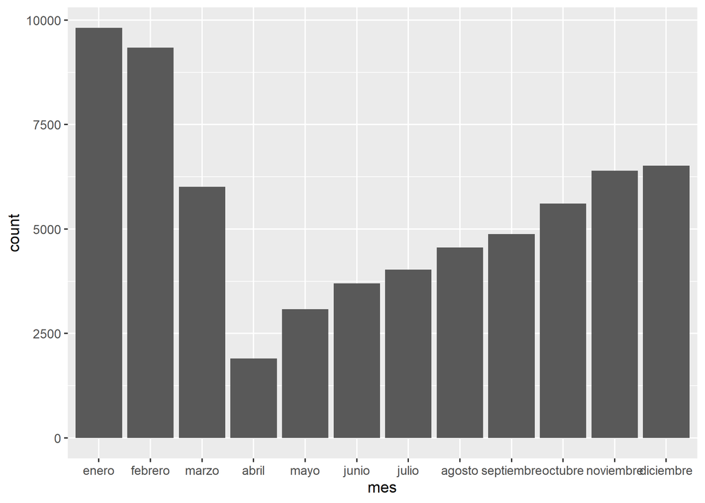

```r
ggplot(delitos_2020) +
    geom_bar(aes(x = mes))
```

¿Detectan algún patrón temporal?

Tal como vimos recién con el *summary()*, en Enero hubo un “pico” de delitos pero gracias al gráfico podemos detectar que en Marzo inicia la caída, llegando a los valores mínimos en Abril y luego retomando de a poco a partir de Mayo. ¿Se les ocurre a qué se debe esto?

Veamos y analicemos un poco los datos a nivel diario (en vez de mensual) para ver si nos dan alguna pista! Para esto, primero hagamos un conteo de delitos por día:

```r
delitos_dia <- delitos_2020 %>%
  group_by(fecha) %>%
  summarise(cantidad=n())
```

Y revisemos los resultados:

```r
head(delitos_dia)
```

```
## # A tibble: 6 × 2
##   fecha      cantidad
##   <date>        <int>
## 1 2020-01-01      231
## 2 2020-01-02      326
## 3 2020-01-03      326
## 4 2020-01-04      314
## 5 2020-01-05      275
## 6 2020-01-06      337
```

```r
summary(delitos_dia)
```

```
##      fecha               cantidad
##  Min.   :2020-01-01   Min.   : 28.0
##  1st Qu.:2020-04-01   1st Qu.:114.0
##  Median :2020-07-01   Median :163.5
##  Mean   :2020-07-01   Mean   :179.9
##  3rd Qu.:2020-09-30   3rd Qu.:236.8
##  Max.   :2020-12-31   Max.   :389.0
```

Podemos ver que, en promedio, durante 2020 ocurrieron 180 delitos por día.

Ahora hagamos un gráfico de líneas que nos muestre como fue esta evolución en el tiempo.

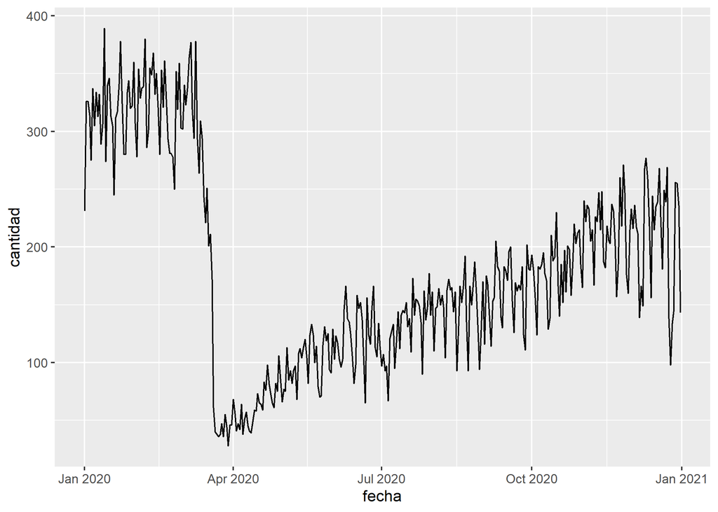

```r
ggplot(delitos_dia) +
    geom_line(aes(x = fecha, y = cantidad))
```

En el gráfico se puede ver de forma muy clara que hubo una caída en la cantidad de delitos a fines de marzo, y todo indicaría que se debe al aislamiento obligatorio por la pandemia.

Agreguemos una línea vertical que marque el día que inició el aislamiento (20/03/2020):

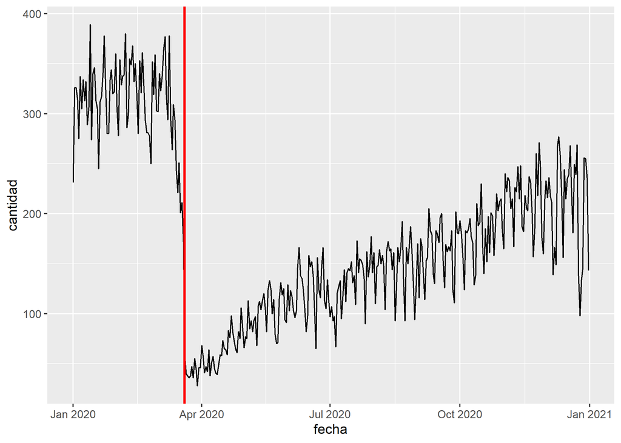

```r
ggplot(delitos_dia) +
    geom_line(aes(x = fecha, y = cantidad)) +
    geom_vline(aes(xintercept=ymd("2020-03-20")), color="red", size=1)
```

Hagamos un poco de “zoom” y filtremos solo el mes de Marzo así vemos con mayor claridad si efectivamente hay un cambio ese día:

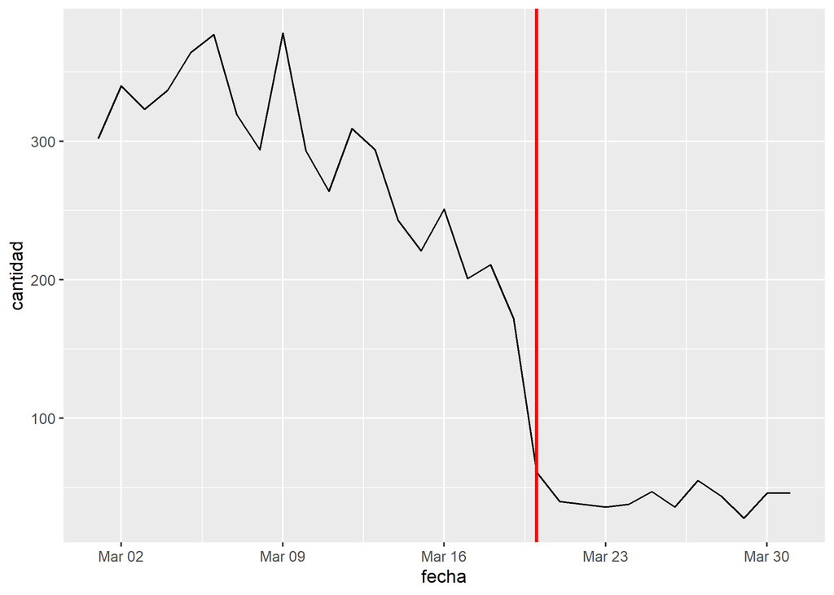

```r
ggplot(delitos_dia %>%
         filter(month(fecha)==03)) +
    geom_line(aes(x = fecha, y = cantidad)) +
    geom_vline(aes(xintercept=ymd("2020-03-20")), color="red", size=1)
```

Ahora si! Lo podemos ver de forma muy clara! Los delitos en CABA cayeron notablemente a partir del 20/03/2020. Ajustemos un poco la estética:

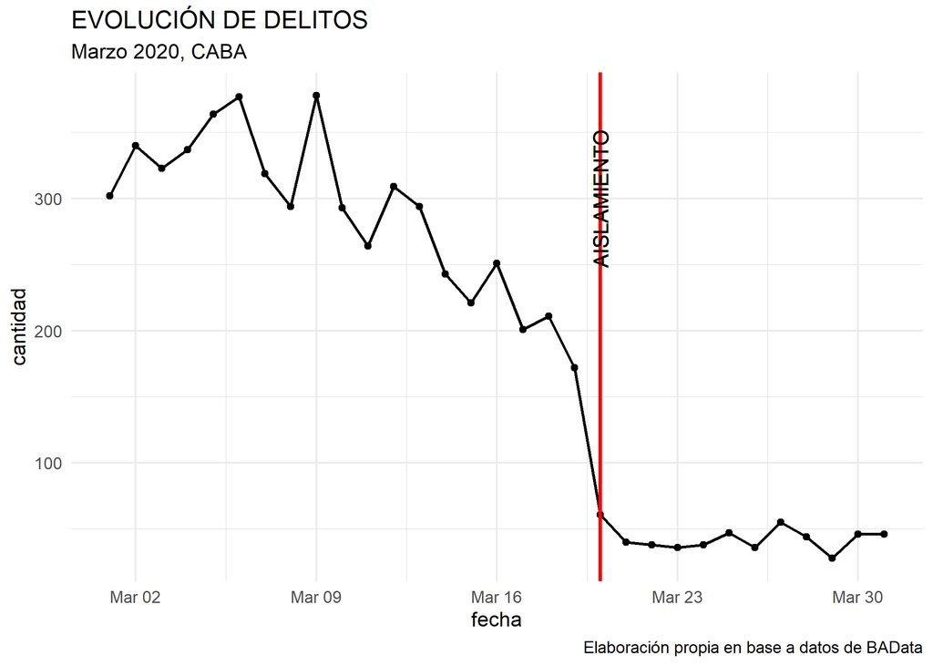

```r
ggplot(delitos_dia %>%
         filter(month(fecha)==03)) +
    geom_line(aes(x = fecha, y = cantidad), size=0.75)+
    geom_point(aes(x = fecha, y = cantidad))+
    geom_vline(aes(xintercept=ymd("2020-03-20")), color="red", size=1)+
    geom_text(aes(x = ymd("2020-03-20"), y = 300, label = "AISLAMIENTO", angle=90))+
    labs(title="EVOLUCIÓN DE DELITOS",
       subtitle="Marzo 2020, CABA",
       caption="Elaboración propia en base a datos de BAData")+
    theme_minimal()
```

Aprovechemos y agreguemos una variable más al primer gráfico de líneas así tenemos nueva información para analizar el patrón temporal de los datos. Probemos con la columna “tipo”, pero en vez de crear un nuevo objeto, hagamos las operaciones *group_by()* y *summarise()* directamente adentro del *ggplot()*:

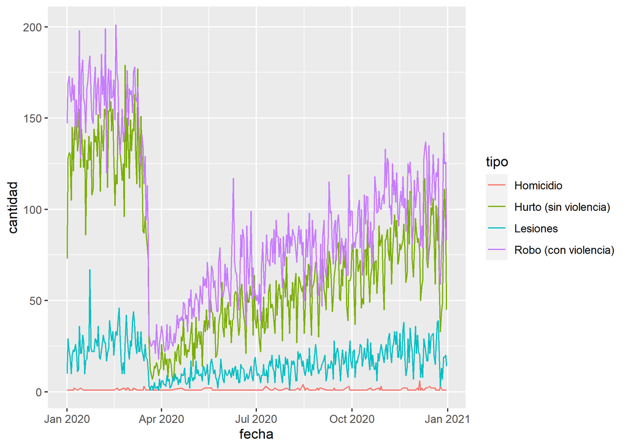

```r
ggplot(delitos_2020 %>%
         group_by(fecha, tipo) %>%
         summarise(cantidad=n())) +
    geom_line(aes(x = fecha, y = cantidad, color=tipo, group=tipo))
```

Tal como vimos al principio de la clase, está muy claro que el tipo/clase de delito que más se registró fue el Robo (con violencia).

Hagamos algunos ajustes estéticos:

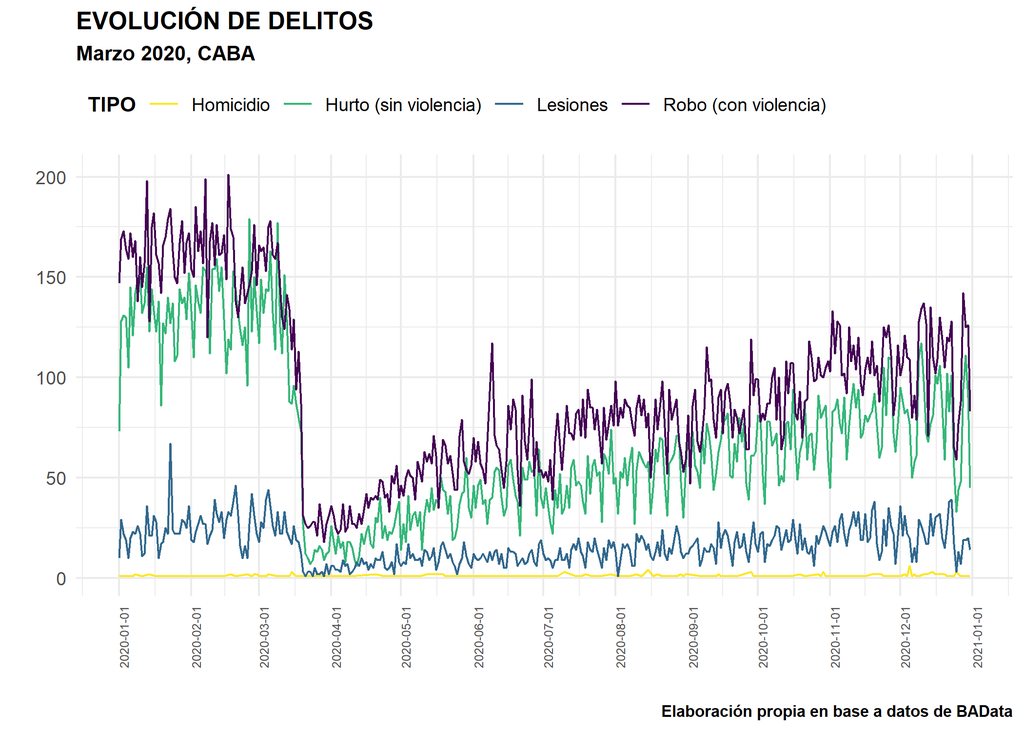

```r
ggplot(delitos_2020 %>%
         group_by(fecha, tipo) %>%
         summarise(cantidad=n())) +
    geom_line(aes(x = fecha, y = cantidad, color=tipo, group=tipo))+
  labs(title="EVOLUCIÓN DE DELITOS",
       subtitle="Marzo 2020, CABA",
       caption="Elaboración propia en base a datos de BAData",
       color="TIPO",
       x="",
       y="")+
  scale_color_viridis_d(direction=-1)+
  scale_x_date(date_breaks = "1 month")+
  theme_minimal()+
  theme(legend.position="top",
        legend.justification = "left",
        title=element_text(size=10, face = "bold"),
        legend.title=element_text(size=10, face = "bold"),
        axis.text.x = element_text(size = 6, angle = 90))
```

Ahora aprovechemos que ya agregamos el día de la semana (dia_semana) en nuestro dataset original y trabajemos con esta unidad de análisis.

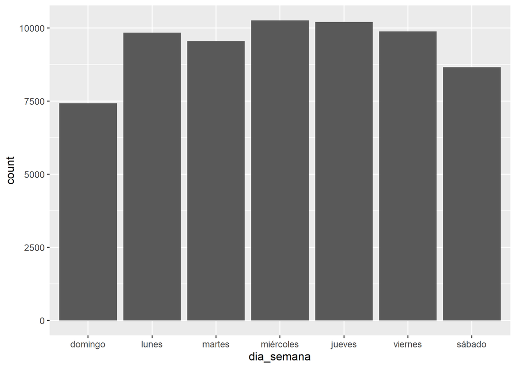

```r
ggplot(delitos_2020)+
  geom_bar(aes(x=dia_semana))
```

Tal como vimos más arriba con *summary()*, el día de la semana que mayor cantidad de delitos registró en 2020 fue el Miércoles, y el que menos fue el Domingo. ¿Se les ocurre a qué se puede deber?

Aprovechemos nuevamente la variable “tipo” y generemos un gráfico de barras apilado que nos de mayor información:

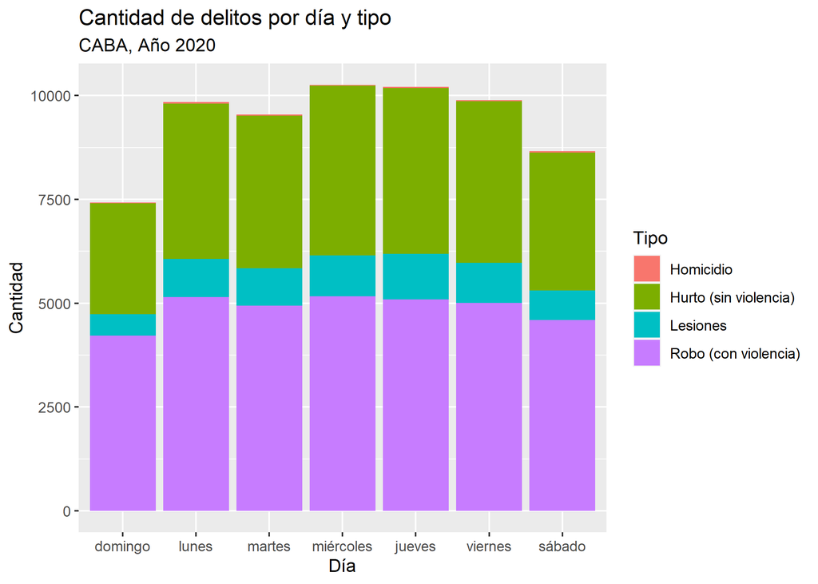

```r
ggplot(delitos_2020)+
  geom_bar(aes(x=dia_semana, fill=tipo))+
  labs(title="Cantidad de delitos por día y tipo",
       subtitle="CABA, Año 2020",
       fill="Tipo",
       x="Día",
       y="Cantidad")
```

El porcentaje (valor relativo) por tipo de delito es muy similar para los 7 días, ¿No?

A priori no podríamos sacar grandes conclusiones, pero quizás si además del día de la semana, analizamos la variable *HORA* podamos obtener más información.

### Horas

Llegó el momento de trabajar con otra unidad de análisis temporal: las **horas** del día.

Comencemos extrayendo la hora utilizando `mutate()`, `hour()` y `hms()` sobre la variable *hora* de nuestro dataset:

```r
delitos_2020 <- delitos_2020 %>%
  mutate(hora=hour(hms(hora)))
```

Ahora agrupemos nuevamente el dataset original pero por día de la semana y hora:

```r
delitos_hora <- delitos_2020 %>%
  group_by(dia_semana, hora) %>%
  summarise(cantidad=n())
```

Y hagamos un gráfico de líneas con la hora en el eje X:

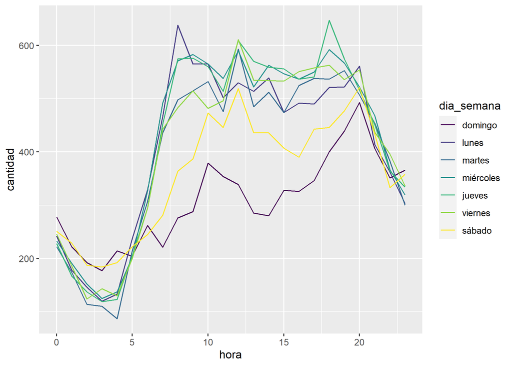

```r
ggplot(delitos_hora) +
    geom_line(aes(x = hora, y = cantidad, color=dia_semana))
```

¿Qué conclusiones pueden sacar a partir del gráfico?

Por ejemplo, se puede ver que durante la madrugada (de 0hs a 4hs aprox), la mayor cantidad de delitos se registran los días sábados y domingos, mientras que, durante el horario laboral (de 8hs a 20hs aprox), la mayor cantidad de delitos registrados se da los días hábiles (de lunes a viernes).

Ajustemos un poco la estética del gráfico para que se vea mejor:

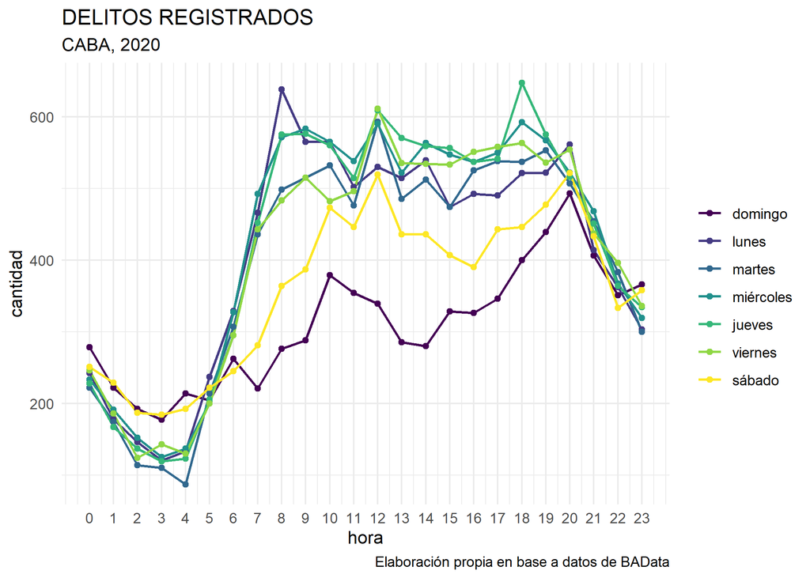

```r
ggplot(delitos_hora) +
    geom_line(aes(x = hora, y = cantidad, color=dia_semana), size=0.75) +
    geom_point(aes(x = hora, y = cantidad, color=dia_semana)) +
    labs(title="DELITOS REGISTRADOS",
       subtitle="CABA, 2020",
       color="",
       caption="Elaboración propia en base a datos de BAData")+
    scale_x_continuous(breaks = 0:23)+
    theme_minimal()
```

Agreguemos una variable más a nuestro gráfico para ver si podemos generar nuevos insights. Probemos facetarlo por el tipo de delito.

Para esto, primero tenemos que agrupar el dataset original por las 3 variables a graficar:

```r
delitos_tipo <- delitos_2020 %>%
  group_by(dia_semana, hora, tipo) %>%
  summarise(cantidad=n())
```

Y luego graficar:

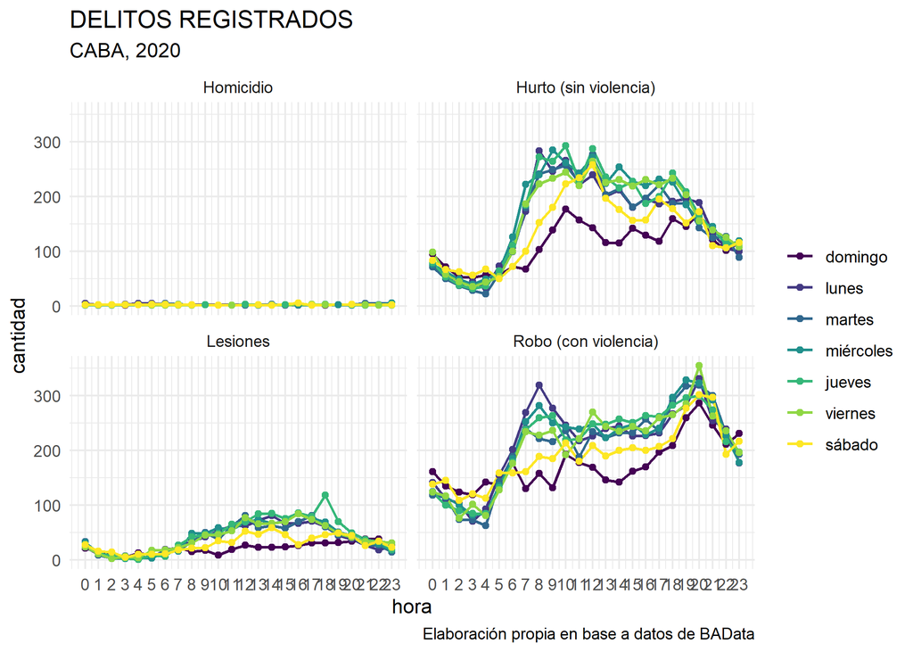

```r
ggplot(delitos_tipo) +
    geom_line(aes(x = hora, y = cantidad, color=dia_semana), size=0.75) +
    geom_point(aes(x = hora, y = cantidad, color=dia_semana))+
    labs(title="DELITOS REGISTRADOS",
       subtitle="CABA, 2020",
       color="",
       caption="Elaboración propia en base a datos de BAData")+
    scale_x_continuous(breaks = 0:23)+
    theme_minimal()+
    facet_wrap(~tipo)
```

¿Pueden sacar alguna conclusión nueva?

Por ejemplo, se puede ver que:

- Homicidio: La cantidad de homicidios es muy menor al resto de delitos, por lo tanto no se pueden sacar conclusiones con este gráfico. Habría que hacer uno específico de Homicidios.
- Lesiones: Se detecta un “pico” los días Jueves a las 18h.
- Hurto (sin violencia): Se registran principalmente entre las 8 y las 12h. Los sábados generalmente hay menos, salvo a las 12h donde se ve un pico que supera a algunos días hábiles.
- Robos (con violencia): Las 8 y a las 20h son los 2 horarios donde se detectan “picos” de registros.

## Ejercicios de práctica

1. Elegir una Ciudad del mundo y descargar algún dataset open data que tenga el dato de fecha y/o hora.
2. Realizar al menos 2 gráficos (líneas y/o barras) que les permitan analizar la temporalidad de los datos. ¿Detectan algún patrón temporal? ¿A qué puede deberse?
3. En todos los gráficos del punto 2, agregar etiquetas (título, subtítulo, etc), y en al menos uno facetarlo y cambiar la paleta de colores.